# Card (1995) — XGBoost Tuning Sensitivity

Predictive losses, estimates, and numerical outcome-weight reproduction

Alexander Unger

27 July 2026

This notebook compares the untuned and fold-specifically tuned XGBoost specifications stored by the two tuning notebooks. It reads the verified exports and does not refit or retune any model.

# 1. Nuisance-prediction losses

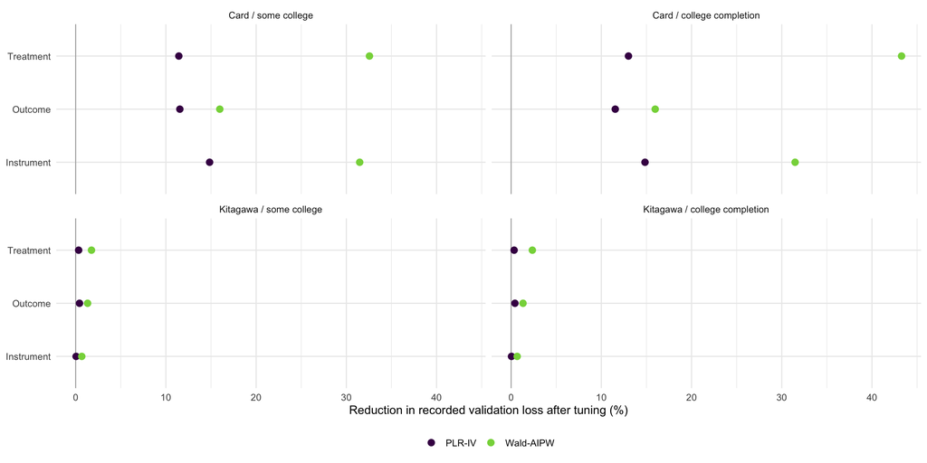

Positive values mean that the tuned specification has a lower recorded validation loss. The loss functions differ across the two estimators and are therefore compared only within estimator and nuisance.

# 2. Point estimates

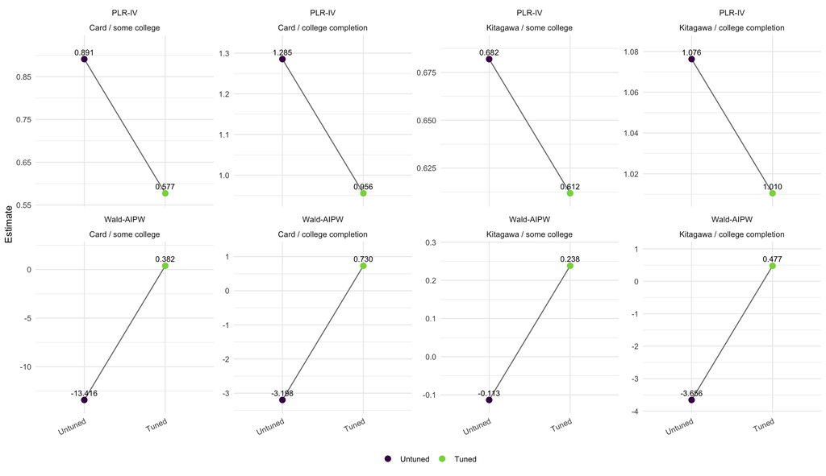

XGBoost estimates: untuned and fold-specifically tuned

| Estimator | Cell | Variant | Estimate | SE |
| --- | --- | --- | --- | --- |
| PLR-IV | Card / some college | Untuned | 0.8910 | 0.3372 |
|  |  | Tuned | 0.5774 | 0.2580 |
|  | Card / college completion | Untuned | 1.2853 | 0.5619 |
|  |  | Tuned | 0.9556 | 0.4586 |
|  | Kitagawa / some college | Untuned | 0.6819 | 0.4022 |
|  |  | Tuned | 0.6119 | 0.3499 |
|  | Kitagawa / college completion | Untuned | 1.0762 | 0.7113 |
|  |  | Tuned | 1.0104 | 0.6554 |
| Wald-AIPW | Card / some college | Untuned | -13.4155 | 14.4111 |
|  |  | Tuned | 0.3821 | 0.2136 |
|  | Card / college completion | Untuned | -3.1980 | 4.0540 |
|  |  | Tuned | 0.7299 | 0.4294 |
|  | Kitagawa / some college | Untuned | -0.1134 | 0.6271 |
|  |  | Tuned | 0.2381 | 0.2577 |
|  | Kitagawa / college completion | Untuned | -3.6561 | 100.9143 |
|  |  | Tuned | 0.4765 | 0.5141 |

The panels use separate vertical scales because the untuned Wald-AIPW estimates and standard errors differ substantially across cells. The table reports the standard errors; the plot is limited to the point-estimate comparison.

# 3. Numerical outcome-weight reproduction

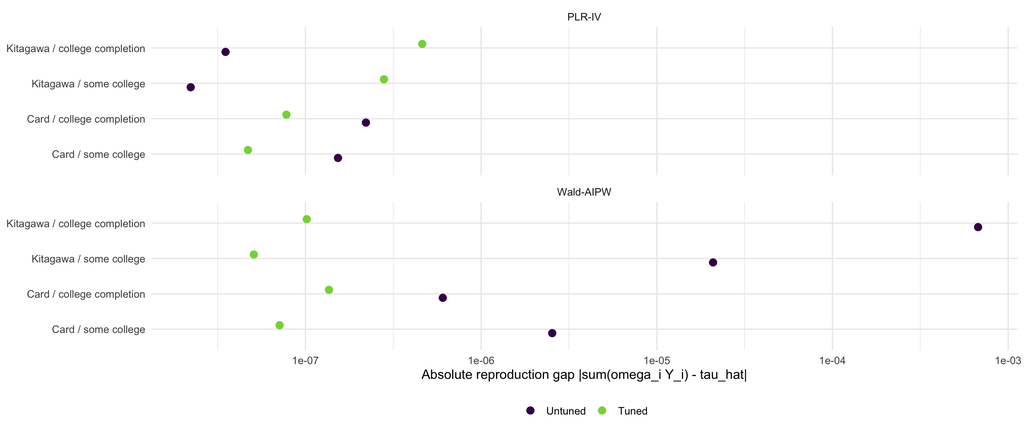

This is a numerical diagnostic for the reconstructed outcome weights. It is not a tuning criterion.

XGBoost outcome-weight representation audit

| Estimator | Cell | Variant | \|ω′Y−τ̂\| | ω′Y reproduces τ̂ |
| --- | --- | --- | --- | --- |
| PLR-IV | Card / some college | Untuned | 1.531000e-07 | FALSE |
|  |  | Tuned | 4.710000e-08 | FALSE |
|  | Card / college completion | Untuned | 2.209000e-07 | FALSE |
|  |  | Tuned | 7.790000e-08 | FALSE |
|  | Kitagawa / some college | Untuned | 2.220000e-08 | FALSE |
|  |  | Tuned | 2.798000e-07 | FALSE |
|  | Kitagawa / college completion | Untuned | 3.510000e-08 | FALSE |
|  |  | Tuned | 4.621000e-07 | FALSE |
| Wald-AIPW | Card / some college | Untuned | 2.538200e-06 | FALSE |
|  |  | Tuned | 7.130000e-08 | FALSE |
|  | Card / college completion | Untuned | 6.051000e-07 | FALSE |
|  |  | Tuned | 1.361000e-07 | FALSE |
|  | Kitagawa / some college | Untuned | 2.090250e-05 | FALSE |
|  |  | Tuned | 5.080000e-08 | FALSE |
|  | Kitagawa / college completion | Untuned | 6.741303e-04 | FALSE |
|  |  | Tuned | 1.017000e-07 | FALSE |

Note:  
Each fitted estimator is assessed separately using Knaus’s all.equal() criterion with R’s default tolerance. A FALSE vector is excluded from normalization, concentration, and balance diagnostics.

# 4. Reading the comparison

The recorded nuisance-prediction losses are lower after tuning in every reported cell and nuisance. The reductions are larger under the Card specification than under the Kitagawa specification.

For PLR-IV, tuning lowers the point estimate in all four cells. For Wald-AIPW, the untuned estimates vary much more across cells, while the tuned estimates lie between 0.238 and 0.730. These comparisons describe the effect of the stated tuning protocol. They do not establish that the tuned causal estimates are closer to the underlying treatment effects.

None of the reconstructed XGBoost vectors passes the estimator-reproduction gate. The notebook therefore does not report normalization, concentration, or balance diagnostics for those vectors. This numerical failure does not remove the XGBoost point estimates from the learner-sensitivity or translation analysis.